# Clustering Algorithms

Yousef Alotaibi

## Topics to be covered..

- Introduction to clustering
- When to use clustering
- Clustering algorithms

## Introduction to clustering

- Clustering is an unsupervised learning method
- The process of clustering involves grouping the data points into a number of groups so that the data points in each group are more similar to one another and different from the data points in the other groups.

[figure not shown]

## Introduction to clustering

- Clustering VS Classification

### Clustering

### Classification

Unsupervised learning

Supervised learning

Unlabeled datasets

Labeled datasets

No need to train and test the dataset

We train and test the dataset to verify the model

Number of groups is unknown

Number of classes is known

algorithms used: K-Means,

algorithms used: Logistic Regression, Random Forest, Decision Trees

## When to use clustering

- Dealing with large unstructered datasets
- Not knowning the number of groups in your dataset
- To identify extreme values

## Clustering algorithms

- K-Means Clustering
- Density-Based Clustering
- Distribution Model-Based Clustering
- Hierarchical Clustering
- Fuzzy Clustering

## K-Means Clustering Process

##### 1- assign K number of clusters (it's best to preform the elbow method to determine the best K number of clusters)

##### 2- assign K number of centroids on the graph randomly

##### 3- calculate the Euclidean distance and assign the points to the nearest centroid

##### euclidean Formula:

[figure not shown]

##### 4- Find the new original centroid in each group

##### 5- Redo step 3 & 4 until the centroids don't change

## K-Means Clustering

[figure not shown]

## K-Means Clustering

[figure not shown]

## K-Means Clustering

[figure not shown]

## K-Means Clustering

[figure not shown]

## K-Means Clustering

[figure not shown]

## K-Means Clustering

[figure not shown]

## K-Means Clustering

[figure not shown]

## K-Means Clustering

[figure not shown]

## How to know what K number of clusters to use

[figure not shown]

## Preforming the Elbo method on the Iris dataset

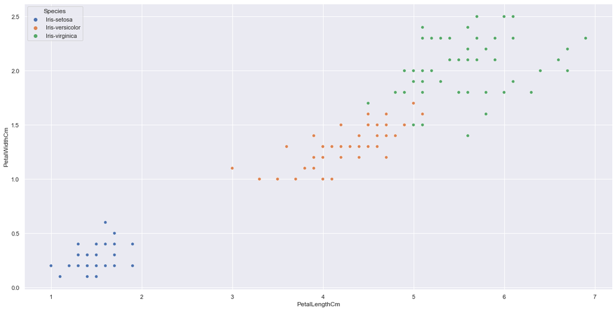

```python
sns.scatterplot(data = d, x = 'PetalLengthCm', y = 'PetalWidthCm', hue='Species')
```

[figure not shown]

```python
x = d.iloc[:, [2,3]].values
sse=[]

for i in range(1,11):
    kmeans = KMeans(n_clusters= i)
    kmeans.fit(X)
    sse.append(kmeans.inertia_)

plt.plot(range(1,11), sse)
plt.title('The Elbow Method')
plt.xlabel('no of clusters')
plt.ylabel('sse')
plt.show()
```

## Citation

- https://www.javatpoint.com/clustering-in-machine-learning
- https://www.analyticsvidhya.com/blog/2021/01/in-depth-intuition-of-k-means-clustering-algorithm-in-machine-learning/